# Hourly Electricity Consumption of Turkey

Ümit Barış Gökkaya - Mete Dibi - 15.02.2021

## 1. Introduction

Electricity has been a vital source of energy in our lives since many centuries. As of today, we can not imagine any tool, gadget etc. that does not require electrical power. The distribution of this resource is handled in the free market, where the producers and the distributors negotiate at a reasonable price, and the distributors offer electricity to households, factories etc. across various regions across the country. Therefore, the market for the electricity distribution is a complex one with many agents. Thus, forecasting methods for the domestic electricity consumption must be carefully analyzed and implemented, since there exist many agents that could be positively/negatively affected from the outcomes.

Of course, a researcher might face some challenges when building such a model for forecasting. The first is the problem of localness, that is, every country might have different consumption structures due to the nature of various things (lifetime habits of citizens, the size of the economy, technological advancement level etc.). Therefore, a researcher might take into account their own country’s characteristics while building such a model.

A second challenge arises due to the nature of some particular times in which the consumption severely rises or falls, which corresponds to outliers in the data. An example would be religious and national holidays in which many people travel abroad and workplaces shut down for a couple of days. Unusual temperature changes might also result in outliers.

The final challenge is due to the COVID-19 pandemic, which has affected various aspects of our lives. Many factories and workplaces remained closed, and some continued to utilize remote working due to observed optimized performance and lower costs. Socializing less has also paved the way for different consumption levels during the day.

In this study, 2 separate models were developed in order to forecast the domestic electrical consumption of Turkey between the period 30.01.2021 and 13.02.2021. Model 1 is an ARIMA(0,0,0)(0,0,1) model that uses transformed daily mean data. Model 2 is a dynamic ARIMA model that iteratively updates itself each day before submission, which uses residual data obtained after a GAM procedure. Fits for made for the data itself, together with 2 day ahead forecasts, and model 2 excelled in both procedures, therefore was used for the forecast submissions for this project. The details of the approaches will be presented in the upcoming sections.

## 2. Related Literature

The below studies were found helpful while conducting the project:

- [GAM: The Predictive Modeling Silver Bullet, KIM LARSEN](https://multithreaded.stitchfix.com/blog/2015/07/30/gam/)

This was a really helpful resource for studying the nature of general additive models(GAM) and splines-regression splines in general.

- Forecasting electricity consumption: A comparison of regression analysis, neural networks and least squares support vector machines (DOI:10.1016/j.ijepes.2014.12.036)

We have benefitted from this paper while we were studying the characteristics of the Turkish electricity market and electricity consumption in general.

- Forecasting: Principles and Practice
- Introduction to Time Series Analysis and Forecasting

The 2 books above were quite rich resources in the time series analysis and forecasting domain in general, and answered some questions we had in mind during various stages of our project.

## 3. The Nature of the Data

As potential predictors to be used in regression, temperature values from 7 different locations in Turkey were available, together with forecasts for future dates. We have experimented with this data in both of our models, however they seemed to have low impact (the details will be shared during the “Approach” section).

The nature of all data was hourly; however, we have also experimented with daily mean values, the details of which we will present in the next section. Using daily rather than hourly data has its own advantages, in particular in terms of speed and ease. Nevertheless, converting daily mean forecasts back to hourly levels must be carefully planned and implemented.

## 4. Initial Insights

Domestic electrical consumption data bears some seasonality of different orders. Below, we analyze plots of different time intervals to describe each aspect our data has.

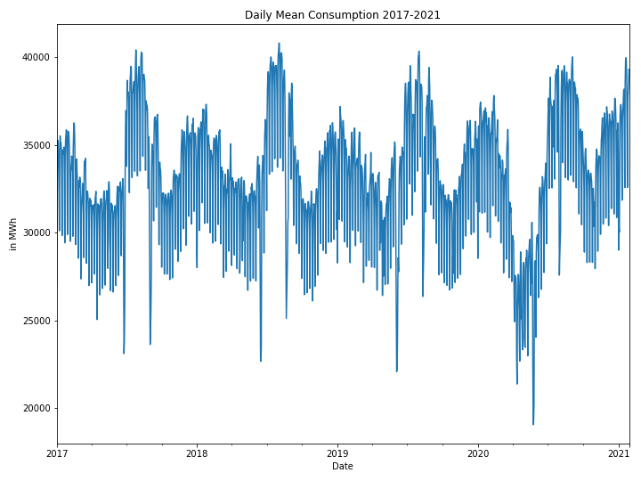

It is generally more efficient to display the line plot of our data via daily means, since the data becomes smoother and it becomes easier to observe various aspects.

As expected, consumption levels tend to increase during summer and winters; most likely due to A/C’s and radiators. Therefore, we observe a constantly changing mean; and the variance seems somehow stable. Notice the outlier values which seem like sudden spikes on the plot. These outlier values are national and religious holidays in most cases, as we’ve discussed.

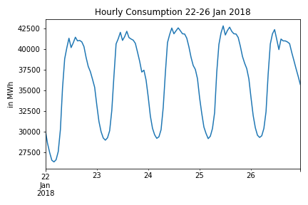

We see a strong hourly seasonality; that is, a particular hour possesses similar values each day. This makes sense, because people tend to follow a similar lifetime routine every day. Also notice how nights have low consumption and middays have high consumption

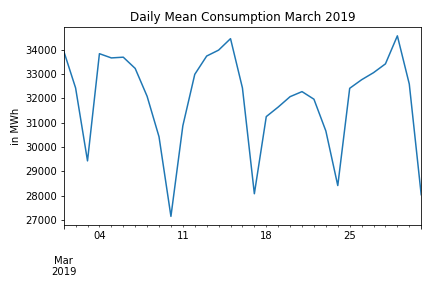

In addition to hourly seasonality, we also observe a daily seasonality; that is, a particular day possesses similar values each week. This also makes sense, since people tend to develop certain habits to perform each day of the week (going out on weekends, performing less in the workplace on Fridays etc.)

Also notice how weekends have low consumption levels, which is reasonable since many workplaces are closed and people tend to spend the day outside with their families, friends etc.

## 5. Methods

In this study, 2 separate models were developed and the superior model was selected after appropriate evaluations. The first model uses daily mean values, and the second model uses the original, hourly values. Below we give very brief descriptions of the methods and techniques used while constructing the aforementioned models.

#### 1) Generalized Additive Models (GAM)

**Difference Between Standard Linear Regression and Generalized Regression**

We begin by considering the standard linear regression model. We have a dependent variable we wish to study, and we believe it to be some function of other variables.

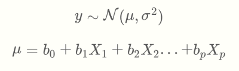

Although theoretically accurate and also very popular, the linear regression model might not perform well when modeling non-linear behaviour of a data. In this case, we choose to use General Additive Models.

**GAM & Splines**

In Generalized Additive Models (GAM), the relationships between the individual predictors and the dependent variable follow smooth patterns that can be linear or nonlinear. We can estimate these smooth relationships simultaneously and then predict the dependent variable by simply adding them up.

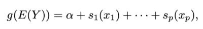

GAM models utilize smoothing splines, which are symbolized as si(xi) above. We will mainly be interested in cyclic cubic regression splines in this study, since they can handle seasonal data elegantly.

#### 2) ARIMA

ARIMA (Auto Regressive Integrated Moving Average) is a modeling method that purely benefits from the past values of a particular data. The AR stands for the auto-regressive term in the model, The MA stands for the moving average term in the model, and the I stands for the difference level. There are methods to apply both non-seasonal and seasonal ARIMA; we have utilized both of them in this study.

Next, we describe the 2 models that were developed for this project.

## 6. Approach

### Model 1: Daily Mean Approach

One can argue that working with daily instead of hourly data is faster and more efficient (unless the size of the data can not accomodate a 1/24 shrink). For the electrical consumption case, our strategy was to aggregate the hourly data for every day, and use the mean of the daily aggregates.

For this model, we have removed the outliers at the initial stage. The outliers mainly consisted of national and religious holidays, but also some days in which the weather exhibited unusual patterns.

One can argue that no initial Box-Cox or log transformation is needed; since the variance seems stable.

Since our daily mean data bears autocorrelation both in levels 1 and 7 (meaning the mean consumption level of every day affects level of the next day and the same day next week), it was seen appropriate to apply both a non-seasonal and seasonal difference, that is;

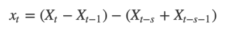

and s = 7 in our case.

After applying the above transformation, the data became stationary, according to unit root test and visual inspection. We had also accounted for the trend (lag 1) and daily seasonality (lag 7). Then, when we analyzed the ACF and PACF plots, we have seen a clear SMA 1 signature(ACF has negative spike at 7; PACF has negative spikes at 7,14,21 and so on):

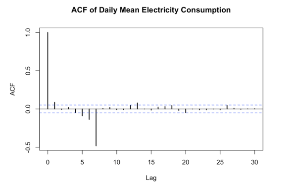

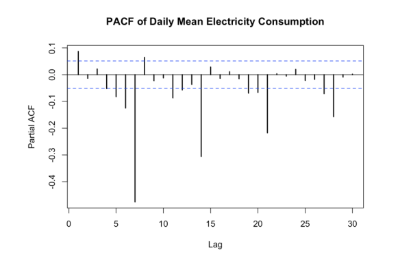

However, although we have built our model for daily mean forecasting, we still had to convert these forecasts to hourly forecasts. For this, we have calculated the proportion of each hour’s average value to the daily mean, and we have carried out this procedure separately for January and February; since the proportions may change for each month due to various factors. After that, we have multiplied these proportions with daily mean forecasts, and obtained our final, hourly forecasts.

When we analyzed the residuals for the fit process on the past data, there seemed no auto-correlation between them; also they exhibited 0 mean with a stable variance. We have also made a single 2-day-ahead forecast, which returned similar residual characteristics. Therefore, our initial model was completed at this stage.

### Model 2: Hourly Level Approach

As a second method, we have chosen to apply a generalized additive method and benefit from cubic regression splines in particular, which can elegantly model non-linearity and handle seasonality in a continuous way.

Just for experimentation purposes, we have not removed outliers (holidays) for this strategy, rather; we have flagged national and religious holidays, the details of which we will discuss very soon.

Again, we also did not apply any Box-Cox or log transformations, since the variance seemed stable.

This second model utilized cyclic cubic regression splines of order 24 (to account for hourly seasonality) and 2 regressors (1 for each type of holiday). When we analyzed the residuals on the test data, the model seemed to have accounted for the hourly seasonality. Nevertheless, the residuals seemed highly autocorrelated at levels 1 and 168, so daily seasonality and a trend was still present. We then applied a transformation by taking differences of order 168(seasonal difference), which made the residuals stationary according to unit root test.

After this, it was seen appropriate to apply non-seasonal ARIMA modeling to the differenced residual series which was stationary.

When we analyzed the ACF and PACF plots for the seasonally differenced residual data, they did not seem to bear any clear AR or MA signature. Therefore, it was seen suitable to proceed with the auto.arima function.

The auto.arima function has returned an ARIMA(3,0,3) model. When fits on the data itself and a 2-day-ahead forecast was made, both residuals seemed independent, with 0 mean and constant variance. Therefore, the 2nd model was completed.

Note that the temperature values were used as regressors during various stages of this model. Nevertheless, we did not see any improvement. This is perhaps due to the nature of the ARIMA model: It captures any temperature change that have occured during the last couple of hours and automatically accommodates this change, also accounting for any effect a temperature change might cause.

### Comparison of Models

When evaluating the performance of the models, WMAPE was chosen as a performance measure. WMAPE’s superiority to other measures arises from its usage of weights, and the WMAPE calculations are universal, so any 2 irrelevant forecast models can be compared by looking at their WMAPE values.

For both models, 2 separate processes were carried out:

- Fitting on the data itself
- Forecasting 2 days ahead

In both of these procedures, both models had no significant bias, no significant residual autocorrelation, residuals had 0 mean and constant variance. However, the second model has resulted in a slightly better WMAPE value. So we have decided to proceed further with this model and make our submissions. The iterative code for the submissions can be found at the end of this study.

## 7. Results, Conclusions and Possible Improvements

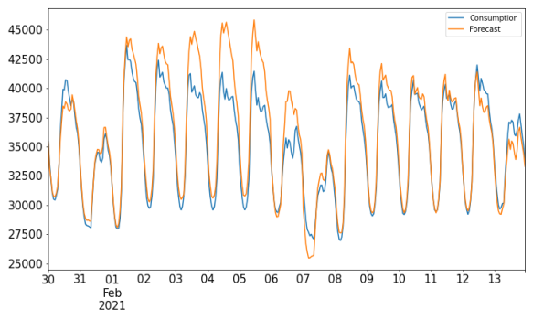

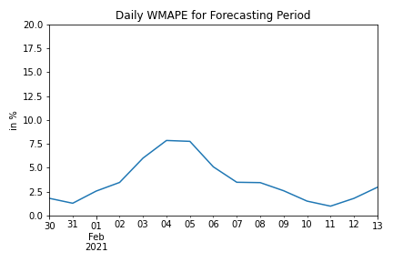

Looking at the residuals from the first week of submissions, it seems that our model overpredicts. Especially during midday hours (in which consumption levels are regularly high) our model results in high negative residuals. The residuals seem to be scattered more randomly in the second week. The reason for that might be the exceptionally high temperatures for the first week: On cooler days, our forecasts are much better.

This finding leads us to conclude that probably we should have benefitted from the temperature data. However, during the analysis, we omitted the temperature regressors because they had a marginal effect on AIC for fitted data, also for our single 2-day-ahead forecast. Perhaps, instead of analyzing a single 2-day-ahead forecast, we should have used a separate test data that contains a longer period; because a single forecast naturally did not show the effect of any temperature changes, therefore underestimated the importance of temperatures as regressors.

Another possible improvement can be to change our approach to seasonality handling: In the second model, we handle hourly seasonality with the help of the splines and daily seasonality with the help of differencing GAM’s residuals of order 168. Perhaps this was not enough and we also had to use seasonal ARIMA. However, applying seasonal auto.arima on a particular data squares the time for the auto.arima function to work (which we experienced and had to wait for long periods), and we couldn’t also clearly see any signature pattern on the ACF & PACF plots, so we had to use auto.arima. Besides, we thought we already handled all types of seasonalities (so there was also no need for seasonal search in the auto.arima function). This was a mistake.

Also, instead of an hourly cubic spline(order 24), an hourly and daily(order 7) could have been used together in the GAM model. Note that we already tried this strategy and it had a marginal effect on the results, therefore we abandoned it. This may again be due to our main mistake-which is not using a long-period test data.

We could have also used the tensor product of hour and day, since tensor products can be used to better model the interaction between daily and weekly seasonality. However, GAM was already a new area for us, and we had some problems when we tried tensor products, and therefore decided not to proceed with them in the limited time we had.

Another possible improvement would be to use the average of Model 1 and Model 2 in every submission, since averaging forecasts of different models is known to be a reliable method with good results in most cases. Or perhaps we could have intervened when the submissions started to get inaccurate and change to Model 1 for submissions.

One last possible modification might be to benefit from different predictors; such as the price of electricity in the free-market or for households, Google Trends data, etc.

Below you may find the code that was used for submissions.

```python
import requests
import json
import warnings
warnings.filterwarnings('ignore')

import numpy as np
import pandas as pd
import matplotlib.pyplot as plt


import rpy2.rinterface
%load_ext rpy2.ipython

%R library(forecast)
%R library(mgcv);
```

```python
URL = 'http://46.101.124.77'

USERNAME = "Group3"
PASSWORD = "EWH56Fz7QhbEMhK1"
submit_now = False  # Set this to True if you want to submit your predictions.


def get_token(username, password):
  body = {"username": username, "password": password}
  r = requests.post(f'{URL}/token/', data=body)
  r = r.json()
  token = r["key"]
  return token


def get_data(token, start_date='2021-01-25'):
  # Date format : YEAR-MONTH-DAY
  header = {'Authorization': f'Token {token}'}
  r = requests.get(f'{URL}/dataset/',
                   params={'start_date': start_date},
                   headers=header)
  r = r.json()
  data = pd.DataFrame.from_dict(r)
  data["event_date"] = pd.to_datetime(data["event_date"])
  data = data.sort_values(by=["event_date"])
  return data


def check_format(predictions):
  assert isinstance(predictions, list)
  for i, pred in enumerate(predictions):
    try:
      predictions[i] = float(pred)
    except:
      error_str = f"Your prediction for Hour = {i} is not a numerical value. Please cast it to either native Python int/floats, or np.number subtype before submission."
      raise ValueError(error_str)


def send_submission(predictions: dict, token: str, submit_now: bool):
  check_format(predictions)
  submission = predictions
  print(f"Your submission will be : {submission}")

  if not submit_now:
    print("You did not submit.")
    return

  submission_body = {"submission": json.dumps(submission)}
  header = {'Authorization': f'Token {token}'}
  r = requests.post(f'{URL}/submission/', data=submission_body, headers=header)

  if r.status_code == 201:
    print(
        "Successfully submitted. Below you can see the details of your submission"
    )

  else:
    print(
        "Could not submit. Please check the error message below, contact the assistant if needed."
    )

  r = r.json()
  print(r)
```

```python
username = USERNAME
password = PASSWORD

token = get_token(username, password)
data = get_data(token, start_date="2021-01-27")

# NEW DATA

data_sorted = data.set_index(pd.to_datetime(data.event_date.astype("str") + ' '
                                            + data.event_hour.astype("str").str.zfill(2),
                                              dayfirst=True)).sort_index();
data_sorted = data_sorted.consumption
data_sorted = data_sorted.to_frame().rename({"consumption":"Consumption"}, axis=1)

# DATA UNTIL 27-01-21

filename = "27012021.csv"
df = pd.read_csv(filename, engine="python")
df.columns = ["Date", "Hour", "Consumption"]
df.Consumption = df.Consumption.str.replace(".", "").str.replace(",", ".").astype("float")
df.set_index(pd.to_datetime(df.Date + ' ' + df.Hour.astype("str").str.zfill(2), dayfirst=True), inplace=True)
df.drop(["Date", "Hour"], axis=1, inplace=True)

# MERGE BOTH

df = pd.concat([df, data_sorted.iloc[:-48]])

# ADD HOLIDAYS

religious_dates = np.array('"2017-06-24" "2017-06-25" "2017-06-26" "2017-06-27" "2017-08-30" "2017-08-31" "2017-09-01" "2017-09-02" "2017-09-03" "2017-09-04" "2018-06-14" "2018-06-15" "2018-06-16" "2018-06-17" "2018-08-20" "2018-08-21" "2018-08-22" "2018-08-23" "2018-08-24" "2019-06-03" "2019-06-04" "2019-06-05" "2019-06-06" "2019-08-10" "2019-08-11" "2019-08-12" "2019-08-13" "2019-08-14" "2020-05-23" "2020-05-24" "2020-05-25" "2020-05-26" "2020-07-30" "2020-07-31" "2020-08-01" "2020-08-02" "2020-08-03"'.replace(" ", ", ").split(","))
religious_dates = [s.replace('"', "").replace(" ", "") for s in religious_dates]
religious_dates_shifted = pd.to_datetime(religious_dates, format='%Y-%m-%d').shift(7, freq="D").astype("str")

holiday_dates = np.array('"2017-04-23" "2018-04-23" "2019-04-23" "2020-04-23" "2017-05-19" "2018-05-19" "2019-05-19" "2020-05-19" "2017-01-01" "2018-01-01" "2019-01-01" "2020-01-01" "2021-01-01" "2018-12-31" "2019-12-31" "2020-12-31" "2017-05-01" "2018-05-01" "2019-05-01" "2020-05-01" "2017-08-30" "2018-08-30" "2019-08-30" "2020-08-30" "2017-10-29" "2018-10-29" "2019-10-29" "2020-10-29" "2017-04-23" "2018-04-23" "2019-04-23" "2020-04-23"'.replace(" ", ", ").split(","))
holiday_dates = [s.replace('"', "").replace(" ", "") for s in holiday_dates]
holiday_dates_shifted = pd.to_datetime(holiday_dates, format='%Y-%m-%d').shift(7, freq="D").astype("str")

df["Date"] = df.index.date
df.Date = df.Date.astype("str")

df["religious_holiday"] = 0

df.loc[df.Date.isin(religious_dates), "religious_holiday"] = 1
df.loc[df.Date.isin(religious_dates_shifted), "religious_holiday"] = -1

df["national_holiday"] = 0

df.loc[df.Date.isin(holiday_dates), "national_holiday"] = 1
df.loc[df.Date.isin(list(holiday_dates_shifted)), "national_holiday"] = -1




hourly = df.copy()
hourly["Hour"] = hourly.index.hour

%R -i hourly

%R formula = as.formula("Consumption ~ religious_holiday + national_holiday + s(Hour, bs='cc', k=24)")
%R gam_model = gam(formula, data=hourly)
%R gf = gam_model$fitted
%R gr = gam_model$residuals
%R -o gf
%R -o gr


hourly["gam_fitted"] = gf
hourly["gam_resid"] = gr

hourly["differ"] = hourly.gam_resid.diff(168)

hourly["lag_resid"] = hourly.gam_resid.shift(168)

%R -i hourly

%R gam_arima_model = auto.arima(hourly$differ)

%R af = gam_arima_model$fitted
%R ar = gam_arima_model$residuals
%R -o af
%R -o ar



hourly_nona = hourly.dropna()

hourly_nona["gam_arima_fitted"] = af
hourly_nona["gam_arima_resid"] = ar


hourly_nona["fitted"] = (hourly_nona.gam_arima_fitted
                         + hourly_nona.gam_fitted
                         + hourly_nona.lag_resid)



forecast_two_days = data_sorted.iloc[-48:].copy()

forecast_two_days["lag_resid"] = hourly_nona.set_index(hourly_nona.index.shift(7, freq="D")).gam_resid
forecast_two_days["Hour"] = forecast_two_days.index.hour

# ADD HOLIDAYS

forecast_two_days[["national_holiday", "religious_holiday"]] = 0

%R -i forecast_two_days
%R gam_pred = predict(gam_model, forecast_two_days, type='response')
%R -o gam_pred
%R forecasted = forecast(gam_arima_model, 48)
%R arima_pred = forecasted$mean
%R -o arima_pred


forecast_two_days["gam_predict"] = gam_pred
forecast_two_days["arima_predict"] = arima_pred

forecast_two_days["forecast"] = forecast_two_days.gam_predict + forecast_two_days.arima_predict + forecast_two_days.lag_resid


prediction = list(forecast_two_days.iloc[24:].forecast.values)

submit_now = True

send_submission(prediction, token, submit_now)
```